# Estatística Básica

Estats Consultoria

22 junho, 2023

# 1 Por que Estatística?

A estatística tem como objetivo levantar dados e informações buscando uma tomada de decisão mais assertiva. Por exemplo, em estudos clínicos, é possível determinar se certo remédio realmente funciona, ou se foi apenas um efeito aleatório no corpo das pessoas, por meio de inferência, também é possível saber a probabilidade de uma lâmpada durar menos de 300 horas de uso, dada sua distribuição, além disso, é possível estimar a média da altura de uma população baseado em uma amostra. No que tange a esse curso, serão abordados alguns assuntos que ajudarão a realizar uma **análise descritiva** mais assertiva, sem achismos.

## 1.1 Análise Descritiva

É a parte inicial de qualquer trabalho estatístico na qual observamos, entendemos e organizamos nossos dados. Nessa etapa, é possível determinar prováveis valores extremos no conjunto de dados, se é capaz de verificar quais são as ocorrências mais frequentes. Nessa parte da análise, são muito utilizados gráficos, tabelas e algumas medidas para resumir os dados e torna-los mais intelígiveis ao pesquisador.  
Nessa etapa, também é possível observar possíveis valores incorretos, por exemplo, em uma base de dados que se tem o registro da idade dos moradores de Maringá, é encontrado uma idade de -10. Obviamente, esse valor está errado, e esse pode ser encontrado, facilmente, via uma análise descritiva. Após identificados valores errados, é feita uma limpeza nos dados.

# 2 Variáveis

Primeiramente, é importante entendermos como são nossos dados e como classificá-los. Precisamos, por exemplo, verificar se esses são números, se são inteiros ou decimais, ou se são categorias, se seguem alguma ordem de importância, como escolaridade, ou não, como estado civil, se podem assumir apenas dois valores, por exemplo, ter diabetes ou não.

## 2.1 Variáveis Qualitativas

De forma resumida, são aquelas que podem ser representadas por palavras, sendo variáveis que exprimem categoria, por exemplo, não é viável representar a altura por meio de palavras. No entanto, quanto a definição de serem representadas por palavras, em alguns casos, pode-se atribuir valores para representar determinadas palavras, um exemplo seria no caso de vacinas, podemos ter uma situação tal que o indivíduo não solicitou, solicitou e recebeu, solicitou e não recebeu. Nesse caso, podemos dizer que não solicitou representa 1, solicitou e recebeu 2, e solicitou e não recebeu 3. Note que em nenhum momento a natureza da resposta foi mudada. Por isso, é interessante que sempre que for fazer essas alterações, se tenha documentado o que cada número representa.  
Esses números são importantes, em especial, para algoritmos de Aprendizado de Máquina. No entanto, esses não serão abordados nesse curso. Caso tenha mais interesse no assunto: [Word Embedding](https://iaexpert.academy/2019/04/12/word-embedding-transformando-palavras-em-numeros/)

### 2.1.1 Variáveis Qualitativas Ordinais

As variáveis qualitativas ordinais são aquelas que possuem uma ordem em seus valores. Como já citado, escolaridade pode ser uma delas, pois um indivíduo começa no fundamental, vai para o médio, ensino superior, mestrado, doutorado. Não é possível começar do doutorado e chegar no fundamental.

### 2.1.2 Variáveis Qualitativas Nominais

As variáveis qualitativas nominais são aquelas que não possuem ordenação nos seus valores. Exemplo, o sexo de um indivíduo. Não faz diferença ser masculino ou feminino, não possui uma ordem de importância.

### 2.1.3 Variáveis Qualitativas Dicotômicas

São aquelas que pode ter apenas dois valores. Exemplo: morto e vivo.

## 2.2 Variáveis Quantitativas

As variáveis quantitativas são aquelas que representam valores exclusivamente numéricos, por exemplo, altura, peso e quantidade de filhos.

### 2.2.1 Variáveis Quantitativas Discretas

Variáveis quantitativas discretas são aquelas que possuem apenas números inteiros, ou seja, que podem ser contadas, como a quantidade de pessoas loiras em uma sala, por exemplo, é uma variável quantitativa discreta.

### 2.2.2 Variáveis Quantitativas Contínuas

Variáveis quantitativas contínuas são aquelas que possuem números quebrados, por exemplo, a altura que é normalmente é representada por duas casas depois da vírgula.

# 3 Medidas de Tendência Central

As medidas de tendência central (ou medidas de centralidade) são medidas utilizadas para representar o conjunto de dados como um todo, resumindo de forma representativa tudo que temos, as três principais sendo Média, Moda, Mediana.

## 3.1 Média

A média é uma estatística que pode ser usado para representar o todo, sendo o ponto de equilibrio dos dados, como na expectativa de vida, espera-se que em média alguém viva esse tempo ou próximo disso. Ela costuma ser a mais utilizada, pois possui boas propriedades, principalmente quando os dados seguem uma curva gaussiana, no entanto, existem casos em que não se é bom utilizá-la.

### 3.1.1 Casos particulares em que a média não é uma boa medida

Que a média é a mais utilizada, já sabemos, no entanto, em casos onde há alta variabilidade dos dados, os dados se distanciam um do outro de forma muito acentuada, ela pode não ser uma boa medida, pois valores extremos tendem a distorce-la.

Exemplo: suponhamos que tenhamos o seguintes dados para idade de pessoas de um curso de estatística:

```r
alunos <- c(18, 18, 19, 20, 23, 20, 21, 22)
mean(alunos)
```

```
## [1] 20.125
```

A idade média dos alunos deu 20.125. Agora, suponhamos que, juntando com essas idades, tenhamos outros dois novos alunos com idades de 50 e 60 anos

```r
alunos <- c(18, 18, 19, 20, 23, 20, 21, 22, 50, 60)
mean(alunos)
```

```
## [1] 27.1
```

Percebamos que a média já foi muito atingida por isso. Uma boa maneira de quantificar se devemos usar ou não a média é pelo coeficiente de variação que será abordado mais a frente.

## 3.2 Moda

A moda é o valor que mais se repete em um conjunto de dados. Exemplo: número de filhos dos empregados de uma empresa

```r
numero_de_filhos <- c(1, 1, 1, 2, 2, 3, 4, 1, 1, 4, 2)

moda <- function(a) {
   uniqv <- unique(a)
   uniqv[which.max(tabulate(match(a, uniqv)))]
}

moda(numero_de_filhos)
```

```
## [1] 1
```

### 3.2.1 Caso Multimodal

O caso multimodal é quando se tem mais de um número repetido. Por exemplo: em uma pesquisa do número de filhos, pode-se ter a mesma quantidade de pessoas com 3 e 4 filhos.

## 3.3 Mediana

A mediana vai servir para vermos em que ponto do conjunto de dados, está o meio das informações. Para calcula-la ordenamos os dados e pegamos o central, devido a isso ela não sofre como valores extremos como a média.

```r
num_alguma_coisa <- c(5, 6, 7, 8, 9, 10, 11, 12)
median(num_alguma_coisa)
```

```
## [1] 8.5
```

No papel, para calculá-la, é necessário determinar se a quantidade de dados é par ou ímpar.  
**Caso par:** Se o número de observações for par, calculamos a média dos valores centrais

```r
observacoes <- c(1, 2, 3, 4, 5, 6, 8, 9)

mediana <- (4 + 5)/2
print(mediana)
```

```
## [1] 4.5
```

**Caso ímpar:** Se o número de observações for ímpar, pegamos apenas o valor central principal

```r
observacoes <- c(1, 3, 3, 6, 7, 8, 9)

mediana <- 6
print(mediana)
```

```
## [1] 6
```

# 4 Medidas de Dispersão

São usadas para determinar o grau de variabilidade dos dados, se os dados se distanciam muito um do outro irá haver uma alta variabilidade.

## 4.1 Amplitude

Representa o intervalo em que nossos dados se encontram, sendo calculada como o maior valor observado subtraído do menor.

## 4.2 Variância

Determina quanto, em média, uma medida se distancia da outra. O problema é que ela é elevada ao quadrado, por isso sua unidade também é elevada ao quadrado, assim não sendo interpretada diretamente.

### 4.2.1 Variância Populacional

Existem dois tipos de variâncias: populacional e e amostral. A populacional será quando o pesquisador poder obter todos os dados possíveis.
$$\sigma^2 =
\frac{\sum_{i=1}^{n}(x_i - \mu)^2} {n}$$

### 4.2.2 Variância Amostral

A amostral será usada quando não for possível obter todos os dados possíveis, alterando o denominador para n-1 por problemas de víes, para mais informações: [Viés de variância](https://towardsdatascience.com/why-sample-variance-is-divided-by-n-1-89821b83ef6d)
$$s^2 =
\frac{\sum_{i=1}^{n}(x_i - \bar{x})^2} {n-1}$$

## 4.3 Desvio Padrão

O desvio padrão é uma estimativa que corrige o problema de unidade de como os dados se dispersam um do outro, sendo interpretado mais facilmente. Para calculá-la, basta extrair a raíz da variância.

### 4.3.1 Desvio Padrão populacional

$$\sigma = \sqrt{\frac{1}{N} \sum_{i=1}^N
(x_i - \mu)^2}$$

### 4.3.2 Desvio Padrão amostral

$$s = \sqrt{\frac{1}{n-1} \sum_{i=1}^n
(x_i - \overline{x})^2}$$

## 4.4 Coeficiente de Variação

O coeficiente de variação tem duas utilidades: comparar desvios médios para duas variáveis onde se tem diferentes escalas, e também para determinar se a média é uma boa medida para resumir os dados.

$$CV = \frac{\sigma}{\mu}$$

# 5 Gráficos

Existem muitos tipos de gráficos para representar variáveis, no entanto, pretendemos focar mais em alguns gráficos: **Gráfico de barras**, **Gráfico de setores (ou pizza)**, **histograma** e **boxplot**.

| Comprimento_Sepala | Largura_Sepala | Comprimento_Petala | Largura_Sepala | Especie |
| --- | --- | --- | --- | --- |
| 5.1 | 3.5 | 1.4 | 0.2 | setosa |
| 4.9 | 3.0 | 1.4 | 0.2 | setosa |
| 4.7 | 3.2 | 1.3 | 0.2 | setosa |
| 4.6 | 3.1 | 1.5 | 0.2 | setosa |
| 5.0 | 3.6 | 1.4 | 0.2 | setosa |
| 5.4 | 3.9 | 1.7 | 0.4 | setosa |
| 4.6 | 3.4 | 1.4 | 0.3 | setosa |
| 5.0 | 3.4 | 1.5 | 0.2 | setosa |
| 4.4 | 2.9 | 1.4 | 0.2 | setosa |
| 4.9 | 3.1 | 1.5 | 0.1 | setosa |

[output cut: 140 more lines]

**Gráfico de barras**: São utilizados retângulos de forma com que a altura fique proporcional a quantidade total. Esse gráfico é, comumente, usado para representar variáveis discretas, ou a frequência de variáveis categóricas. Por exemplo, ele pode ser usado para entender como se comporta o número de cilindros dos carros nessa categoria.

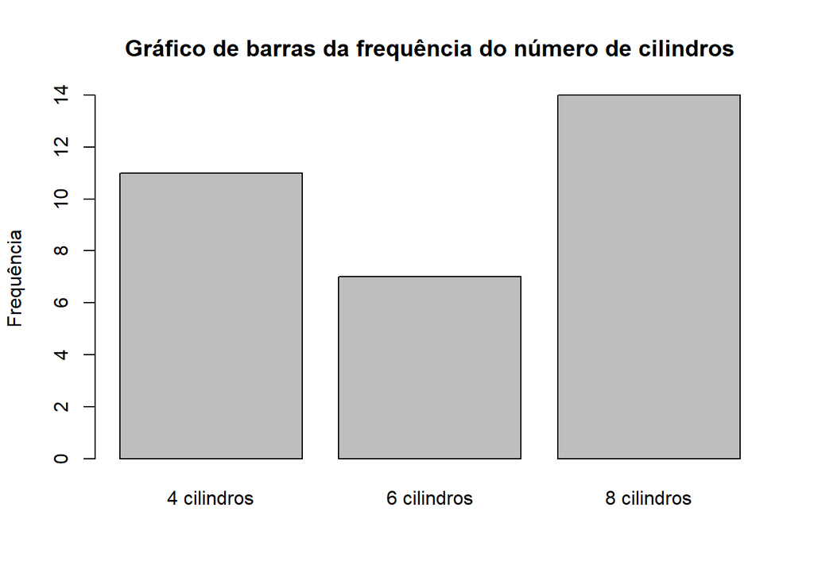

**Gráfico de Pizza**: É um círculo dividido em pedaços. Cada pedaço representa um valor numérico que tem área proporcional ao seu valor. Esse, é um gáfico que devemos tomar muito cuidado ao utiliza-lo, sendo recomendado apenas se tivermos duas categorias, pois mais que isso perdemos a noção visual do quanto uma parte do gráfico é maior que outra.

Fazendo o mesmo exemplo para o gráfico de pizza, notaremos que não é mais tão fácil perceber e quantificar a diferença da frequência entre 4 e 6 cilindros.

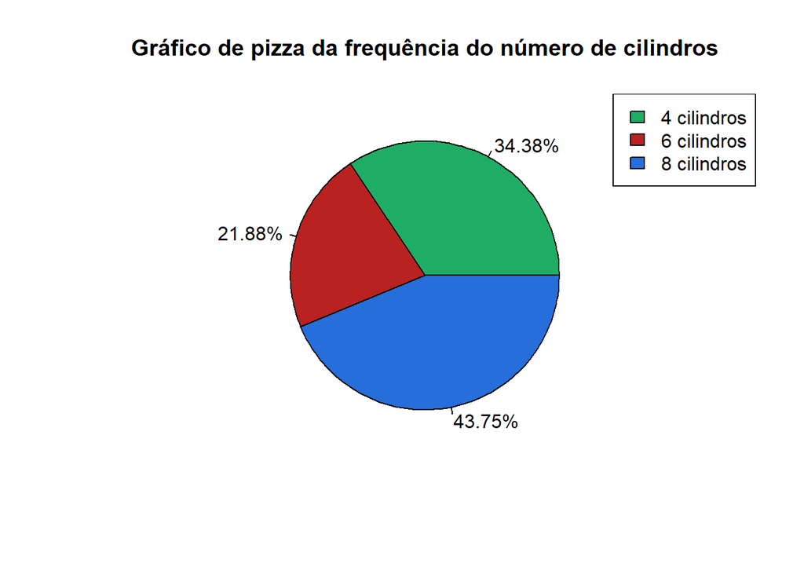

Agora respeitando o limite de no utilizar duas categorias, notaremos que mesmo visualmente conseguimos perceber que a transmissão automática é presente em um pouco mais que 50% dos carros da amostra, quanto a manual é o valor complementar.

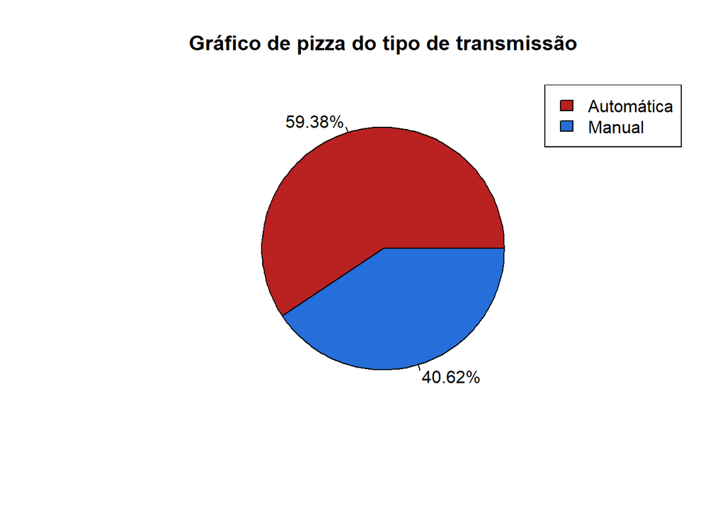

**Histograma**: É um gráfico utilizado para variáveis quantitativas contínuas, sendo constituído de barras uma ao lado da outro. Prosseguindo usando o mesmo banco, agora, como exemplo, queremos verificar a distribuição do peso dos carros.

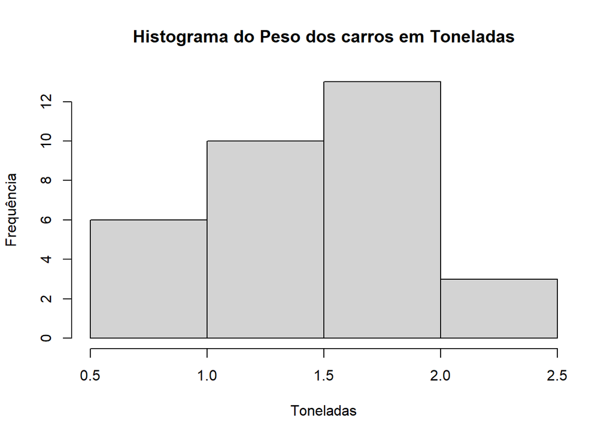

**Boxplot**: É um gráfico, como o histograma, usado principalmente para variáveis quantitativas contínuas. Esse mostrando várias estátisticas importantes, mostrando os quartis, a mediana, o formato da distribuição e os candidatos a outliers. O gráfico é constituído de uma caixa, uma barra e alguns pontos que são os possíveis outliers.

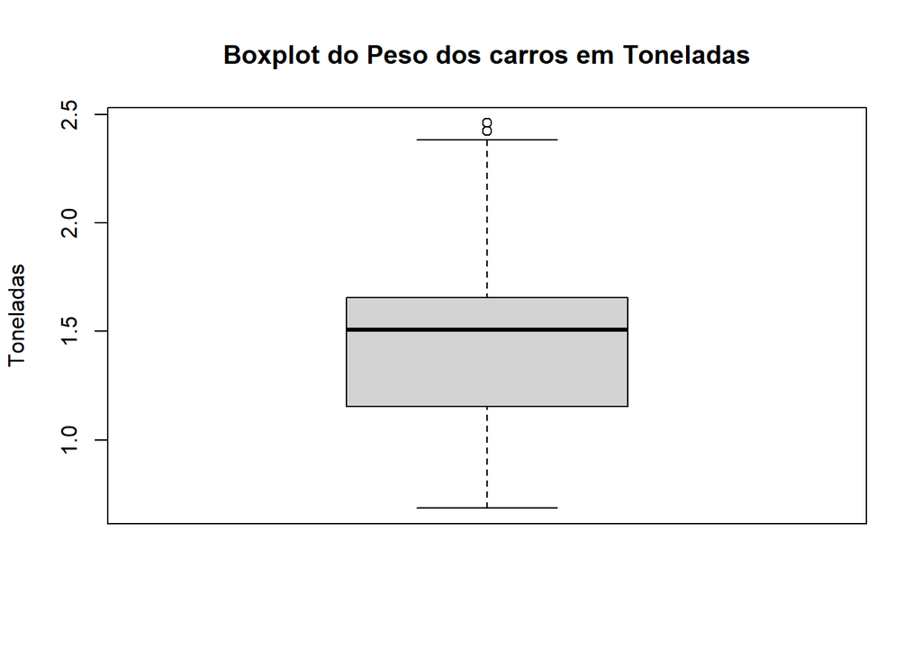

# 6 Tabelas de frequência

```
## Frequencies
## dados_mtcars$Milhas_por_Galao
## Type: Numeric
##
##               Freq   % Valid   % Valid Cum.   % Total   % Total Cum.
## ----------- ------ --------- -------------- --------- --------------
##        10.4      2      6.25           6.25      6.25           6.25
##        13.3      1      3.12           9.38      3.12           9.38
##        14.3      1      3.12          12.50      3.12          12.50
##        14.7      1      3.12          15.62      3.12          15.62
##          15      1      3.12          18.75      3.12          18.75
##        15.2      2      6.25          25.00      6.25          25.00
##        15.5      1      3.12          28.12      3.12          28.12
##        15.8      1      3.12          31.25      3.12          31.25
##        16.4      1      3.12          34.38      3.12          34.38
##        17.3      1      3.12          37.50      3.12          37.50
##        17.8      1      3.12          40.62      3.12          40.62
##        18.1      1      3.12          43.75      3.12          43.75
##        18.7      1      3.12          46.88      3.12          46.88
##        19.2      2      6.25          53.12      6.25          53.12
##        19.7      1      3.12          56.25      3.12          56.25
##          21      2      6.25          62.50      6.25          62.50
##        21.4      2      6.25          68.75      6.25          68.75
##        21.5      1      3.12          71.88      3.12          71.88
##        22.8      2      6.25          78.12      6.25          78.12
##        24.4      1      3.12          81.25      3.12          81.25
##          26      1      3.12          84.38      3.12          84.38
##        27.3      1      3.12          87.50      3.12          87.50
##        30.4      2      6.25          93.75      6.25          93.75
##        32.4      1      3.12          96.88      3.12          96.88
##        33.9      1      3.12         100.00      3.12         100.00
##        <NA>      0                               0.00         100.00
##       Total     32    100.00         100.00    100.00         100.00
```

# 7 Referências

Bussab, WO; Morettin, PA. Estatística Básica. São Paulo: Editora Saraiva, 2010 (6ª Edição).